# Week_9

mcgrathjes

2025-09-26

## Week 9 Practical

```r
suppressPackageStartupMessages({
  library("seqinr") # is a package designed to process and analyse sequence data.
  library("R.utils") # general utilities like zip and unzip
})
```

## Loading sequence data

We will be downloading E. coli genomic sequence data from Ensembl. Ensembl is one of the biggest databases of genomic data. There are many E. coli strains available in Ensembl, but we will focus today on “Escherichia coli str. K-12 substr. MG1655 str. K12 (GCA_000005845)”.

```r
library("R.utils")

URL="http://ftp.ensemblgenomes.org/pub/bacteria/release-53/fasta/bacteria_0_collection/escherichia_coli_str_k_12_substr_mg1655_gca_000005845/cds/Escherichia_coli_str_k_12_substr_mg1655_gca_000005845.ASM584v2.cds.all.fa.gz"
download.file(URL,destfile="ecoli_cds.fa.gz")
#gunzip("ecoli_cds.fa.gz")
list.files()
```

```
## [1] "CopyOfknit1.Rmd"       "ecoli_cds.fa"          "ecoli_cds.fa.gz"
## [4] "gradcert-SLE777.Rproj" "LICENSE"               "README.md"
## [7] "Week9.html"            "Week9.Rmd"
```

## Load seqinr library

Load the seqinr library: This library provides tools for biological sequence retrieval and analysis.

```r
library("seqinr")
```

## Reading the fasta file

The code below reads the uncompressed FASTA file ecoli_cds.fa containing Escherichia coli coding sequences into R using the read.fasta function from the seqinr package. The str(head(cds)) function then provides a structured summary of the first few sequences, giving an overview of the data’s structure and content.

```r
cds <- seqinr::read.fasta("ecoli_cds.fa")
str(head(cds))
```

```
## List of 6
##  $ AAC73112: 'SeqFastadna' chr [1:66] "a" "t" "g" "a" ...
##   ..- attr(*, "name")= chr "AAC73112"
##   ..- attr(*, "Annot")= chr ">AAC73112 cds chromosome:ASM584v2:Chromosome:190:255:1 gene:b0001 gene_biotype:protein_coding transcript_biotyp"| __truncated__
##  $ AAC73113: 'SeqFastadna' chr [1:2463] "a" "t" "g" "c" ...
##   ..- attr(*, "name")= chr "AAC73113"
##   ..- attr(*, "Annot")= chr ">AAC73113 cds chromosome:ASM584v2:Chromosome:337:2799:1 gene:b0002 gene_biotype:protein_coding transcript_bioty"| __truncated__
##  $ AAC73114: 'SeqFastadna' chr [1:933] "a" "t" "g" "g" ...
##   ..- attr(*, "name")= chr "AAC73114"
##   ..- attr(*, "Annot")= chr ">AAC73114 cds chromosome:ASM584v2:Chromosome:2801:3733:1 gene:b0003 gene_biotype:protein_coding transcript_biot"| __truncated__
##  $ AAC73115: 'SeqFastadna' chr [1:1287] "a" "t" "g" "a" ...
##   ..- attr(*, "name")= chr "AAC73115"
##   ..- attr(*, "Annot")= chr ">AAC73115 cds chromosome:ASM584v2:Chromosome:3734:5020:1 gene:b0004 gene_biotype:protein_coding transcript_biot"| __truncated__
##  $ AAC73116: 'SeqFastadna' chr [1:297] "g" "t" "g" "a" ...
##   ..- attr(*, "name")= chr "AAC73116"
##   ..- attr(*, "Annot")= chr ">AAC73116 cds chromosome:ASM584v2:Chromosome:5234:5530:1 gene:b0005 gene_biotype:protein_coding transcript_biot"| __truncated__
##  $ AAC73117: 'SeqFastadna' chr [1:777] "a" "t" "g" "c" ...
##   ..- attr(*, "name")= chr "AAC73117"
##   ..- attr(*, "Annot")= chr ">AAC73117 cds chromosome:ASM584v2:Chromosome:5683:6459:-1 gene:b0006 gene_biotype:protein_coding transcript_bio"| __truncated__
```

# Basic Sequence Analysis

Now we can figure out the number of coding sequences.

```r
length(cds)
```

```
## [1] 4239
```

The summary(cds) function generates a detailed summary of the sequences, including their lengths, classes, and modes, while head limits the output to the initial entries.

```r
head(summary(cds))
```

```
##          Length Class       Mode
## AAC73112   66   SeqFastadna character
## AAC73113 2463   SeqFastadna character
## AAC73114  933   SeqFastadna character
## AAC73115 1287   SeqFastadna character
## AAC73116  297   SeqFastadna character
## AAC73117  777   SeqFastadna character
```

Now let’s determine the total length of our sequence. The code below extracts the lengths of genes from the cds object by converting the first column of the summary to numeric values. It then calculates the total length of all genes by summing these values.

```r
len <- as.numeric(summary(cds)[,1])

sum(len)
```

```
## [1] 3978528
```

Average

```r
mean(len)
```

```
## [1] 938.5534
```

Median

```r
median(len)
```

```
## [1] 831
```

We can look at the distribution of coding sequence length with different types of plots.

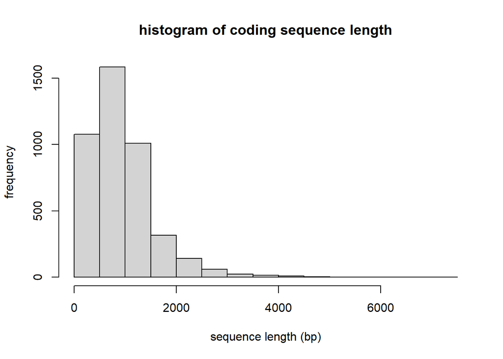

```r
hist(len,xlab="sequence length (bp)",ylab="frequency",main="histogram of coding sequence length")
```

Box plot view

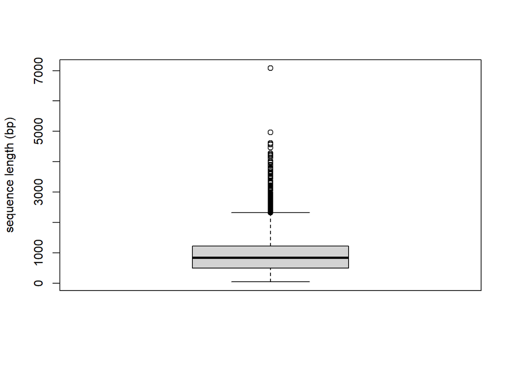

```r
boxplot(len,ylab="sequence length (bp)")
```

# Sequence composition

Composition of DNA sequences.

First with one sequence, then with the whole set of coding sequences.

use ?GC ?count and ?summary to see the documentation for those seqinr commands.

cds is a list containing multiple sequences. To access a specific element within a list, such as the first sequence, we use double square brackets ([[ ]]). This syntax retrieves the actual sequence object from the list. For example, cds[[1]] extracts the first sequence from the cds list. We can then pass this to the GC function to compute its GC content.

```r
GC(cds[[1]])
```

```
## [1] 0.5151515
```

Let’s count the number of each nucleotide present in this gene.

```r
count(cds[[1]],1)
```

```
##
##  a  c  g  t
## 21 22 12 11
```

We can also calculate the occurrence of two-nucleotide combinations in our first gene.

```r
count(cds[[1]],2)
```

```
##
## aa ac ag at ca cc cg ct ga gc gg gt ta tc tg tt
##  3 10  2  5 11  7  3  1  2  4  4  2  4  1  3  3
```

```r
count(cds[[1]],3)
```

```
##
## aaa aac aag aat aca acc acg act aga agc agg agt ata atc atg att caa cac cag cat
##   1   2   0   0   1   7   2   0   0   1   1   0   0   1   1   3   0   6   1   4
## cca ccc ccg cct cga cgc cgg cgt cta ctc ctg ctt gaa gac gag gat gca gcc gcg gct
##   7   0   0   0   0   1   2   0   0   0   1   0   1   0   0   0   2   0   1   1
## gga ggc ggg ggt gta gtc gtg gtt taa tac tag tat tca tcc tcg tct tga tgc tgg tgt
##   0   1   1   2   1   0   1   0   1   2   1   0   1   0   0   0   2   1   0   0
## tta ttc ttg ttt
##   3   0   0   0
```

If you want to count the total length or compute the GC content of a specific number of genes from a list, you will need to unlist them first. For instance, length(unlist(cds[1:3])) extracts the first three sequences from the cds list, converts them into a single character vector using unlist, and then calculates the total length of this combined vector.

```r
length(unlist(cds[1:3]))
```

```
## [1] 3462
```

And if you want to measure the GC content of these three genes you wrap it with GC function instead of length

```r
GC(unlist(cds[1:3]))
```

```
## [1] 0.5389948
```

Unlist everything

```r
length(unlist(cds))
```

```
## [1] 3978528
```

```r
GC(unlist(cds))
```

```
## [1] 0.5193114
```

DNA composition of whole genome

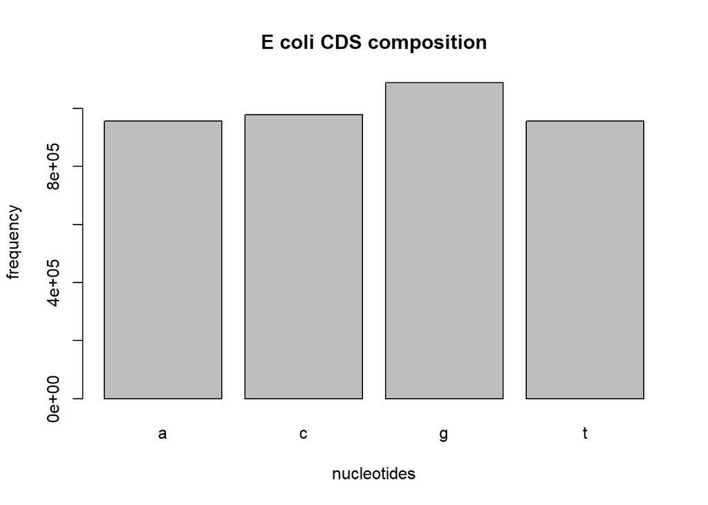

```r
dna <- unlist(cds)
dna_composition <- count(dna,1)
barplot(dna_composition,xlab="nucleotides",ylab="frequency", main="E coli CDS composition")
```

Relative frequencies of each nucleotide

```r
dna_composition/sum(dna_composition)
```

```
##
##         a         c         g         t
## 0.2402316 0.2457175 0.2735939 0.2404570
```

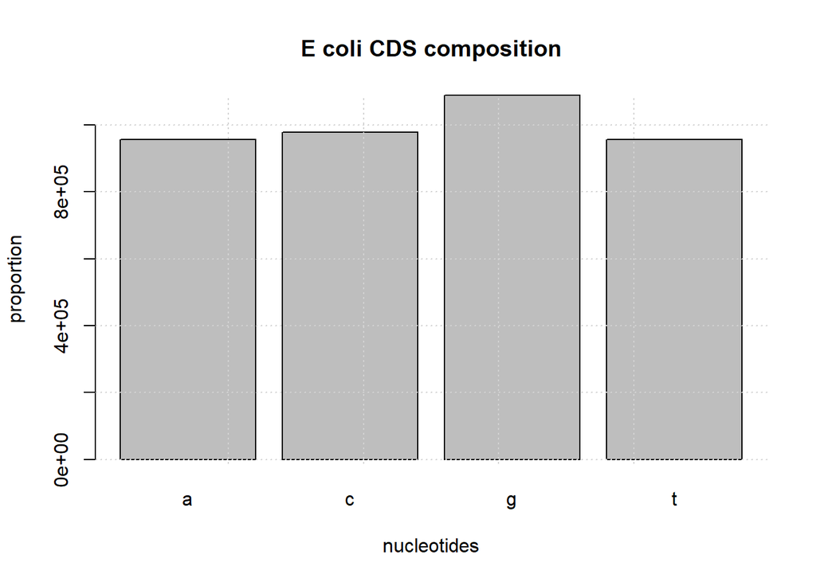

```r
barplot(dna_composition,xlab="nucleotides",ylab="proportion", main="E coli CDS composition")

grid()
```

## Translation

```r
translate(cds[[1]])
```

```
##  [1] "M" "K" "R" "I" "S" "T" "T" "I" "T" "T" "T" "I" "T" "I" "T" "T" "G" "N" "G"
## [20] "A" "G" "*"
```

Translating the whole genome

```r
prot <- lapply(cds, translate)
```